# Does clone-censor-weighting carry modelling bias?

Modelling-bias QBA of the CCW analysis in the Maringe lung cancer example: simple and nested adjustment (draft v0.65)

Author

Artis Luguzis

Published

October 27, 2026

**ImportantKey answer**

The CCW analysis of the Maringe example was replayed 10,000 times on the original 200 patients with the generating effect calibrated so that the **average** CCW estimate equals the observed one (paper Section 2.7.1), and 10,000 times with no surgery effect. **Bias:** small but detectable. **95% CI coverage:** below nominal. **Type I error:** inflated. After the non-parametric QBA adjustment, checked in an independent set of 10,000 studies per scenario, the bias is 0.002, CI coverage 94.9%, consistent with 95%, and type I error 5.30%, consistent with 5%. The nested simulation, which re-estimates the whole adjustment in each of 1250 outer datasets, gives coverage 93.8%, consistent with 95% and type I error 6.96%, above 5% (Monte Carlo error about 1 percentage point, Section 5).

|  | CCW as published | Simple adjustment | Nested simulation |
| --- | --- | --- | --- |
| HR, surgery within 6 months vs not (95% CI) | 0.6206 (0.3691–1.0433) | 0.6305 (0.3683–1.1216) | 0.6305 (0.3630–1.1227) |
| p-value | 0.072 | 0.117 (simulation-calibrated) | — |
| Bias, log HR (95% MC interval) | **-0.016 (-0.027 to -0.005)** | 0.002 (-0.006 to 0.010) | -0.006 (-0.024 to 0.012) |
| 95% CI coverage (target 95%) | **93.7% (0.2%)** | 94.9% (0.2%) | 93.8% (0.7%) |
| Type I error (target 5%) | **7.550% (0.264%)** | 5.300% (0.224%) | **6.960% (0.720%)** |
| RMSE, log HR | 0.285 | 0.285 | 0.277 |

Estimate (MCSE). Bold: differs from the target by more than 1.96 MCSE. CCW: 10,000 studies per scenario. Simple adjustment: learned from these, checked in 10,000 independent studies per scenario. Nested: 1250 outer datasets × 50 inner studies, every adjustment step repeated per outer dataset.

**What changed since the 22 October report** (manuscript v0.65, 24 Oct):

- **Calibration** starts at θ = −0.7 (the search stops at once if the mean estimate is already within tolerance); the grace period is exactly 180 days.
- **Performance measures:** RMSE and MSE = RMSE² are reported everywhere; power is no longer calculated.
- **Additional analyses** (paper 4.6, Section 6): second endpoint (survival difference at 12 months), generalized-gamma prediction model, hypothetical-trial target for an estimator that is not consistent.
- **Nested split** (paper Appendix, Section 6.4): inner and outer runs chosen from a pilot study.

**Earlier changes** (manuscript v0.64, 17 Oct):

- **Inverse calibration** (2.7.1): θ* is now chosen so that the *mean CCW estimate* over simulated studies equals the observed estimate; the adjusted estimate is the true CCW effect at θ*, ψ(θ*) = observed − bias(θ*). Previously θ* made the *true* CCW effect equal the observed estimate.
- **Non-parametric adjustments** (2.7.2–2.7.3): CI from the quantiles of the centred Monte Carlo errors; test from the quantiles of the centred no-effect estimates, with separate lower and upper limits. Parametric versions are kept as a secondary check.
- **Independent check** of the adjusted analysis in a separate set of simulated studies (replaces two-fold cross-fitting).
- **Nested (double) simulation** (2.7.2), presented next to the simple adjustment.
- The simulation bootstrap-t and confidence belt are no longer part of the default run (switch on in `config/belt.yml`).

# 1. What was done

| Paper step | What it means here |
| --- | --- |
| 1. Fit the reference model | Run the CCW analysis on the original data (Section 1.1). |
| 2. Keep baseline data | All covariates **and each patient’s actual surgery date** are kept unchanged. |
| 3. Predict outcomes | New death times from a Weibull model fitted to the data, in which surgery changes the hazard **from the day it takes place**. Censoring is predicted as well (Section 2.3). |
| 4. Repeat | 10,000 simulated studies at θ* and at θ = 0 (20,000 CCW analyses; 0 failed). |
| 5. Re-analyse | The same CCW function as on the real data. |
| 6. Quantify | Bias, RMSE (and MSE = RMSE²), CI coverage and type I error, each with Monte Carlo SE. |
| 7. Adjust | Inverse calibration and bias correction; non-parametric CI and test; checked in independent studies (Section 4) and by a nested simulation (Section 5). |

## 1.1 Data and analysis

The dataset is the simulated example distributed with Maringe et al. (2020; `ccwr::lungcancer`): 200 elderly patients with stage I–II lung cancer, followed from diagnosis for one year. 106 had surgery (42 on day 1) and 48 died. It is not the registry cohort of their Table S2, but the table below uses the same layout.

Patient characteristics by surgery during follow-up.

|  | Received surgery N | % | Did not receive surgery N | % | SMD (%) |
| --- | --- | --- | --- | --- | --- |
| **Total** | 106 | 100.0 | 94 | 100.0 |  |
| **Sex** |  |  |  |  |  |
| Men | 56 | 52.8 | 51 | 54.3 | -2.9 |
| Women | 50 | 47.2 | 43 | 45.7 |  |
| **Performance status** |  |  |  |  |  |
| 0 | 46 | 43.4 | 11 | 11.7 | 75.9 |
| 1 | 54 | 50.9 | 41 | 43.6 | 14.7 |
| 2 | 6 | 5.7 | 42 | 44.7 | -100.7 |
| **Charlson’s comorbidity index** |  |  |  |  |  |
| 0 | 48 | 45.3 | 34 | 36.2 | 18.6 |
| 1 | 40 | 37.7 | 39 | 41.5 | -7.7 |
| 2 | 18 | 17.0 | 21 | 22.3 | -13.5 |
| **TNM stage** |  |  |  |  |  |
| I | 76 | 71.7 | 53 | 56.4 | 32.3 |
| II | 30 | 28.3 | 41 | 43.6 |  |
| **Route to diagnosis** |  |  |  |  |  |
| Emergency | 11 | 10.4 | 20 | 21.3 | -30.2 |
| Non-emergency | 95 | 89.6 | 74 | 78.7 |  |
|  | Median | Q1 Q3 | Median | Q1 Q3 |  |
| **Age at diagnosis (years)** | 76.3 | 73.0 79.9 | 81.2 | 76.7 84.9 | -66.1 |
| **Deprivation score** | 0.15 | 0.07 0.28 | 0.14 | 0.07 0.26 | 14.0 |
| **Time to surgery (days)** | 25 | 1 43 |  |  |  |

[output not shown]

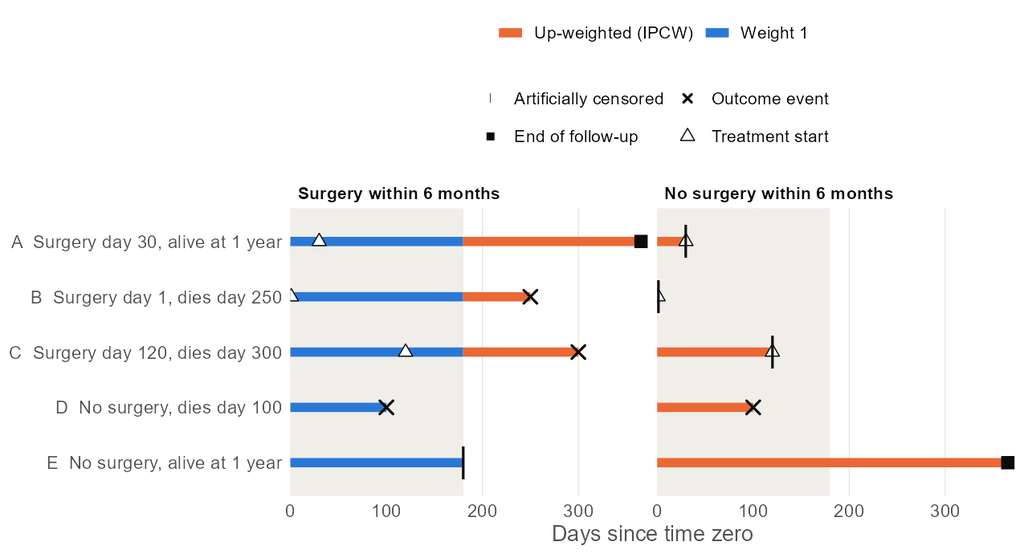

Figure 1: How example patients are cloned into both strategies, when each clone is artificially censored, and which part of follow-up carries a censoring weight (drawn with the analysis code’s own rules). Shaded: grace period.

**Covariate balance at 6 months** (as Figure S2 of Maringe et al.). Among clones still at risk at the end of the grace period, the arms differ strongly before weighting; the censoring weights reduce, but do not remove, these differences.

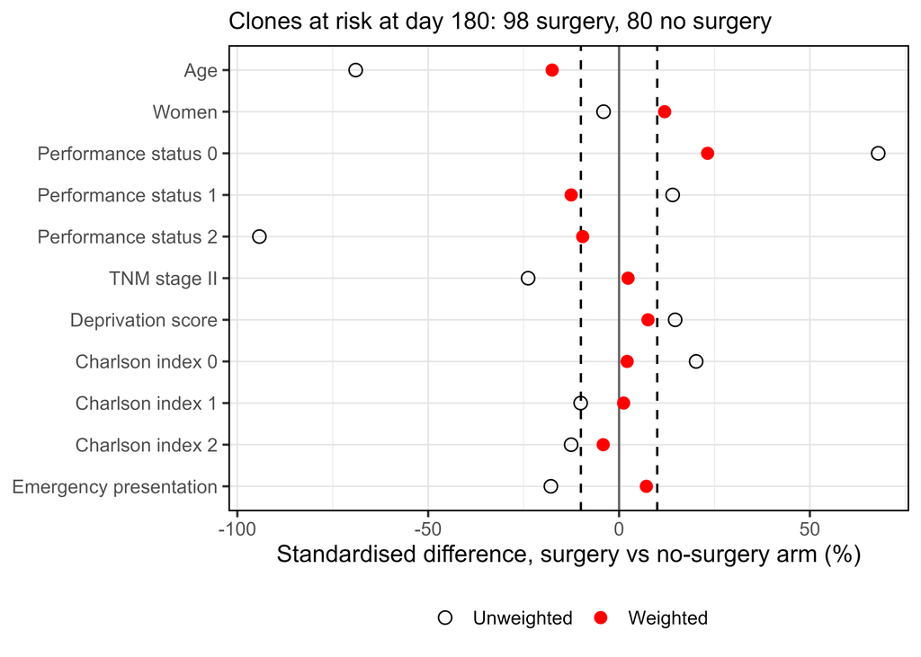

Figure 2: Standardised differences between the surgery and no-surgery arms among clones at risk at day 180, before and after censoring weights. Dashed lines: ±10%.

Before weighting, 10 of 11 covariate terms differ by more than 10% (largest 94.2%); after weighting, 4 still do (performance status 0 23.2%, age -17.5%, performance status 1 -12.5%, sex 11.9%). In the registry data of Maringe et al. all weighted differences were within 10%; in this 200-patient example the weight models leave residual imbalance, consistent with the CCW estimate staying below HR = 1 with no surgery effect even with unlimited data (Section 2.2).

## 1.2 Run time

Computing time of the full pipeline by stage (sum over targets, all workers).

| Stage | Minutes | Share | Units | Seconds per unit |
| --- | --- | --- | --- | --- |
| Nested simulation, outer datasets at θ* | 2594.1 | 73% | 1,250 outer datasets | 124.517 |
| Nested simulation, outer datasets with no effect | 398.5 | 11% | 1,250 outer datasets | 19.126 |
| Data, model fits, summaries, tables, figures, report | 168.8 | 5% |  |  |
| Independent check of the simple adjustment | 128.6 | 4% | 20,000 CCW analyses of 200 patients | 0.386 |
| Simulated studies | 126.4 | 4% | 20,000 CCW analyses of 200 patients | 0.379 |
| True values ψ(θ*) and ψ(0) | 108.2 | 3% | 48 large datasets of 50,000 | 135.275 |
| Inverse calibration of θ* | 16.4 | 0% | 4,000 CCW analyses of 200 patients | 0.245 |

# 2. How the simulation works

## 2.1 Simulate patients, not the CCW

CCW is an analysis procedure (cloning, artificial censoring, censoring weights, weighted outcome model), not a model of how outcomes arise, so nothing can be drawn from it directly. The outcome-generating model is a patient-level model fitted to the original data: Weibull survival with surgery as a time-varying exposure, h(t) = h₀(t)·exp(γ′X + θ·1{t ≥ surgery date}). Covariates and surgery dates are kept (paper Step 2) and new death times are drawn. Each simulated dataset looks like the original data, and the whole CCW procedure is re-run on it.

## 2.2 True value and inverse calibration

θ is the effect of surgery *once received*, at fixed covariates. The CCW hazard ratio compares *strategies* and differs from θ (grace-period dilution, non-proportional strategy hazards, non-collapsibility). The true value is the probability limit of the CCW analysis in the simulated world, ψ(θ) = plim ψ̂<sub>N</sub>(θ) (paper 2.7.1): the base data are copied to 50,000 patients, outcomes are simulated and the same CCW function is run; this is repeated 24 times and averaged.

**Inverse calibration.** θ* is searched so that the *mean* CCW estimate over simulated studies of the original size, m(θ), equals the observed estimate (secant search, 2,000 simulated studies per step with common random numbers, so m(θ) is smooth in θ):

Inverse calibration path: mean CCW estimate m(θ) over simulated studies of 200 patients.

| Step | θ (log HR) | Weibull HR exp(θ) | m(θ), mean CCW log HR | Mean CCW HR |
| --- | --- | --- | --- | --- |
| 1 | -0.700 | 0.4966 | -0.488 | 0.6142 |
| 2 | -0.683 | 0.5052 | -0.477 | 0.6203 |

Result: θ* = -0.683 (Weibull HR 0.5052), against the fitted coefficient θ̂ = -0.415 (HR 0.6605). Over all 10,000 studies at θ*, the mean CCW estimate is -0.484 (HR 0.6160; observed -0.477, residual 0.007). The true value is ψ(θ*) = -0.469 (HR 0.6259, MCSE 0.005), so the bias at θ* is -0.016 (MCSE 0.006) and the adjusted estimate is ψ̂<sub>obs</sub> − b(θ*) = -0.461 (HR 0.6305). The residual of the search does not matter: ψ̂<sub>obs</sub> − b(θ*) equals ψ(θ*) plus the residual, the paper’s identity to first order.

**No-effect scenario (θ = 0).** Every patient’s outcome is then identical under both strategies, so the truth is 0 and no calibration is needed (paper 2.7.3). The large-sample value ψ(0) = -0.041 (HR 0.9603) is a diagnostic: CCW is off-centre even with unlimited data.

## 2.3 Censoring (paper Section 2.3)

`fit_dgm()` fits a second Weibull model with the event/censoring indicator switched (loss to follow-up is the event), same covariates, surgery as a time-varying term; `simulate_outcomes()` draws censoring times by the same inversion and sets follow-up to min(event, censoring, end of study). In the Maringe data all 152 survivors are followed to day 365.24, so there is no censoring event to model: the predicted censoring is administrative at one year for every patient (`censoring: none`). Artificial censoring of clones is produced by the CCW analysis itself in every replay.

# 3. Performance of the CCW analysis (paper 2.6)

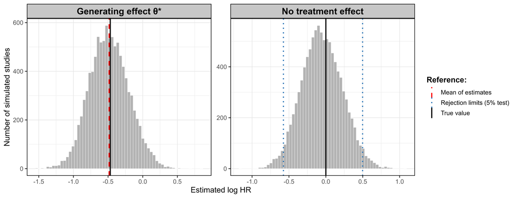

Figure 3: Simulated CCW estimates at the calibrated generating effect θ* (left; true value and mean of estimates) and with no surgery effect (right; true value and the non-parametric rejection limits of a 5% test).

**Bias.** At θ* the average estimate is HR 0.6160 against a truth of 0.6259: a bias of -0.016 on the log scale (MC 95% interval -0.027 to -0.005), 5.6% of one empirical SE.

**Coverage.** The empirical SE is 0.285, the average robust SE 0.274 (3.7% too small). Coverage is 93.7% (MCSE 0.2%). The misses are lopsided: 4.4% of CIs lie entirely below the true HR and 1.9% above (2.5% each expected), because estimates and SEs are correlated.

**Type I error.** With no surgery effect, 7.550% (MCSE 0.264%) of studies reject H0: HR = 1 at 5%; 6.310% in favour of surgery. The no-effect estimates are centred at HR 0.9485.

**RMSE.** At θ*, RMSE = 0.285 (MCSE 0.002) and MSE = RMSE² = 0.0813 (MCSE 0.0011); MSE = bias² + empirical SE² up to the Monte Carlo error of the truth.

# 4. Simple adjustment (paper 2.7.1–2.7.3)

Observed analysis, calibration and QBA adjustment.

|  | Value |
| --- | --- |
| Observed CCW HR (95% CI) | 0.6206 (0.3691 to 1.0433) |
| Observed p-value | 0.072 |
| Prediction model: on-treatment HR (exp(theta-hat)) | 0.6605 |
| Calibrated generating HR, exp(theta*), with mean CCW estimate = observed | 0.5052 |
| Mean CCW estimate at theta* over the simulated studies (MCSE, log HR) | 0.6160 (0.003) |
| True CCW value at theta*, psi(theta*) (MCSE of psi, log HR) | 0.6259 (0.005) |
| Bias at theta*, log HR (MCSE) | -0.016 (0.006) |
| Large-sample CCW value with no treatment effect, psi(0) | 0.9603 |
| QBA-adjusted HR, simple adjustment (non-parametric 95% CI) | 0.6305 (0.3683 to 1.1216) |
| QBA-adjusted HR, nested simulation (non-parametric 95% CI) | 0.6305 (0.3630 to 1.1227) |
| QBA-adjusted HR, parametric 95% CI (CI inflation factor) | 0.6305 (0.3676 to 1.0814); k = 1.04 |
| Non-parametric 5% test: H0 rejected if CCW estimate is below / above | 0.5626 / 1.6453 |
| Simulation-calibrated p-value (non-parametric) | 0.117 |
| Nested: SD of the estimated bias correction across outer datasets (within MC error) | 0.043 (0.044) |

- **Estimate** (2.7.1): ψ(θ*) = ψ̂<sub>obs</sub> − b(θ*), with b(θ*) = m(θ*) − ψ(θ*) from the 10,000 studies at θ*.
- **CI, non-parametric** (2.7.2, 5a): the studies at θ* are centred at their mean; the 2.5% and 97.5% quantiles of these errors (-0.538 and 0.576) are added to the adjusted estimate. Parametric alternative: adjusted estimate ± 1.96 × 1.04 × robust SE.
- **Test, non-parametric** (2.7.3, 7): the no-effect estimates are centred at their mean (-0.053); H0 is rejected if the observed estimate minus that mean falls below the 2.5% or above the 97.5% quantile, i.e. if the CCW HR is below 0.5626 or above 1.6453. Simulation-calibrated p-value: twice the smaller tail share, 0.117 (observed 0.072). Parametric alternative: centred |z| with critical value 2.07, p = 0.128.

**Does it work?** The adjustment learned from the 10,000 studies above was applied unchanged to 10,000 *independent* studies per scenario (own seed stream; paper 2.7.2 step 5c and 2.7.3 step 9). The MCSEs below treat the learned CI and rejection limits as fixed, i.e. they describe the rule as it would be applied to the study. The limits themselves were estimated from 10,000 studies, so the true error rate of any such learned rule varies by about ±0.22% (SD) around its target. Including this, the simple adjustment deviates from nominal by z = -0.29 for coverage and z = 0.95 for type I error; more no-effect studies would narrow the latter.

Performance of the CCW analysis, the simple adjustment (independent studies) and the nested simulation (estimate (MCSE)).

| Performance measure | CCW as published | Simple adjustment | Nested simulation |
| --- | --- | --- | --- |
| Mean estimate, log HR (true value) | -0.484 (-0.469) | -0.466 (-0.469) | -0.475 (-0.469) |
| Bias, log HR (MCSE) | -0.016 (0.006) | 0.002 (0.004) | -0.006 (0.009) |
| Relative bias, % of empirical SE | -5.6 | 0.8 | -2.2 |
| Empirical SE (MCSE) | 0.285 (0.002) | 0.285 (0.002) | 0.277 (0.006) |
| Model-based (robust) SE | 0.274 |  |  |
| Relative error in model SE, % | -3.7 |  |  |
| RMSE (MCSE) | 0.285 (0.002) | 0.285 (0.002) | 0.277 (0.006) |
| MSE = RMSE^2 (MCSE), log HR^2 | 0.0813 (0.0011) | 0.0810 (0.0011) | 0.0770 (0.0032) |
| 95% CI coverage, % (MCSE) | 93.7 (0.2) | 94.9 (0.2) | 93.8 (0.7) |
| CI entirely below / above the true value, % | 4.4 / 1.9 | 1.9 / 3.2 | 3.3 / 3.0 |
| Type I error, % (no effect) | 7.550 (0.264) | 5.300 (0.224) | 6.960 (0.720) |
| Rejections favouring surgery, % (no effect) | 6.310 | 2.630 | 4.560 |
| Simulated studies | 10,000 per scenario (0 failed) | 10,000 per scenario | 1250 outer x 50 inner (2 failed) |

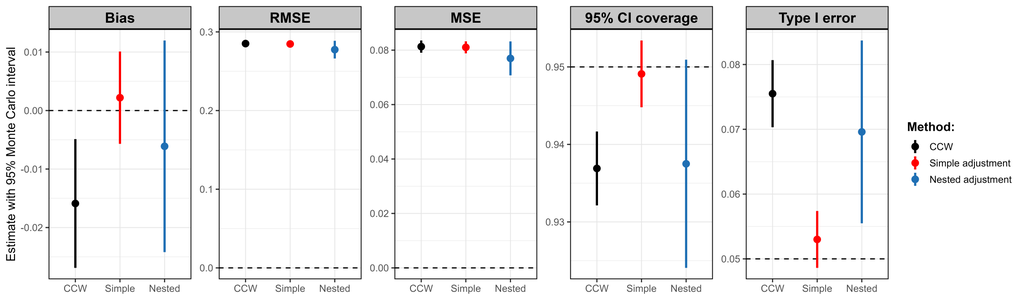

Figure 4: Bias, RMSE, 95% CI coverage and type I error: CCW as published, simple non-parametric adjustment (independent studies) and nested simulation. Bars: 95% Monte Carlo interval. Dashed: nominal value.

**Form of the non-parametric CI.** The paper adds the error quantiles to the estimate, [ψ̃ + q<sub>2.5</sub>, ψ̃ + q<sub>97.5</sub>]. If the error distribution is skewed, the interval that inverts it exactly is the reflected one, [ψ̃ − q<sub>97.5</sub>, ψ̃ − q<sub>2.5</sub>]. Here the centred errors are right-skewed (quantiles -0.538 and 0.576). Overall coverage is 94.9% for the paper’s form and 95.0% for the reflected form (MCSE 0.2%). The share of CIs entirely below / above the true value is 1.9% / 3.2% for the paper’s form; the reflected form misses 2.7% below and 2.3% above (2.5% each expected):

Coverage of the CI variants, % (MCSE), and the share of CIs entirely below or above the true value (2.5% each expected).

| Analysis | CI | Coverage | Below truth | Above truth |
| --- | --- | --- | --- | --- |
| CCW | Wald (robust SE) | 93.7 (0.2) | 4.4 | 1.9 |
| CCW | Wald (robust SE), validation set | 93.7 (0.2) | 4.7 | 1.6 |
| Simple adjustment | Non-parametric | 94.9 (0.2) | 1.9 | 3.2 |
| Simple adjustment | Non-parametric (reflected) | 95.0 (0.2) | 2.7 | 2.3 |
| Simple adjustment | Parametric | 94.8 (0.2) | 3.6 | 1.6 |
| Nested adjustment | Non-parametric | 93.8 (0.7) | 3.3 | 3.0 |
| Nested adjustment | Non-parametric (reflected) | 94.1 (0.7) | 3.8 | 2.2 |

# 5. Nested simulation (paper 2.7.2)

The simple adjustment treats the fitted prediction model, θ* and the bias correction as known. The nested simulation repeats the whole adjustment in each of 1250 outer datasets, as it would be done for the study data:

1. Outer dataset: simulated at θ* from the fitted model (baseline data and surgery dates kept); CCW estimate ψ̂<sub>r</sub>. The outer datasets are the first 1250 of the independent studies of Section 4, so both adjustments are compared on the same data.
2. Refit the Weibull prediction model to the outer dataset.
3. Inverse calibration with the refitted model: θ<sub>r</sub> with m<sub>r</sub>(θ<sub>r</sub>) = ψ̂<sub>r</sub> (Newton step from θ*, then secant; 50 inner studies per step, common random numbers; 2.52 steps on average, 0 at the |θ| bound).
4. True value ψ<sub>r</sub>(θ<sub>r</sub>) under the refitted model (2 large datasets of 25,000).
5. Bias b<sub>r</sub> = m<sub>r</sub>(θ<sub>r</sub>) − ψ<sub>r</sub>(θ<sub>r</sub>); adjusted estimate ψ̃<sub>r</sub> = ψ̂<sub>r</sub> − b<sub>r</sub>; non-parametric CI from the inner studies at θ<sub>r</sub>.
6. Coverage: share of outer CIs that contain the true value used to generate the outer data, ψ(θ*) = -0.469.

With no effect, each outer dataset gets its own refitted model, 50 inner no-effect studies and its own rejection limits; type I error is the share of outer datasets in which H0 is rejected.

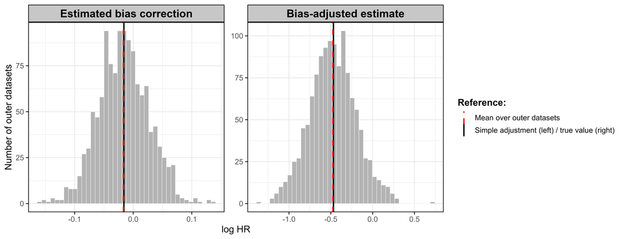

Figure 5: Nested simulation: estimated bias correction b_r (left; black: correction of the simple adjustment) and bias-adjusted estimate (right; black: true value ψ(θ*)) across outer datasets.

**Results.** 1248 of 1250 outer datasets (and 1250 of 1250 with no effect) completed. The calibrated θ<sub>r</sub> varies across outer datasets (mean -0.762, SD 0.531), following the outer estimates. The estimated bias correction has mean -0.017 (simple adjustment: -0.016) and SD 0.043 across outer datasets, of which 0.044 is the Monte Carlo error within each outer dataset; the genuine variation of the correction is therefore not distinguishable from zero, against an empirical SE of 0.285. The nested CI of the observed analysis is 0.3630–1.1227, against 0.3683–1.1216 from the simple adjustment.

- **Coverage** of the outer CIs: 93.8% (0.7%); on the same outer datasets the simple adjustment’s fixed correction covers 95.4%.
- **Type I error** with refitted limits: **6.960% (0.720%)**; fixed limits of the simple adjustment on the same datasets: 4.720%.
- **Nested CI of the observed analysis:** the centred 2.5% and 97.5% quantiles of the outer bias-adjusted estimates (-0.552, 0.577) added to the adjusted estimate, so it includes the variation of the estimated bias correction.
- With 50 inner studies, each outer CI and rejection limit rests on few tail studies; this noise is part of what the nested coverage and type I error measure. More inner studies (`nested: inner` in `config/config.yml`) bring the nested results closer to those of the procedure as applied to the study data (10,000 studies).

# 6. Additional analyses (paper 4.6)

## 6.1 Survival difference at 12 months

Same data, clones, weights and prediction model; the estimand is the difference between the weighted proportions alive at day 365 (arm 1 − arm 0, IPC-weighted, Hájek form; SE from the patient-clustered influence function with the weights treated as known). Direction: a larger difference favours surgery, so the rejection direction and the “favouring” rates are mirrored relative to the log HR. Calibration starts at θ = −0.7 as well. Differences are in percentage points.

Observed difference 11.39 points; calibrated θ* = -0.793 (HR 0.4523) after 2 evaluations. Adjusted difference 11.33 points (non-parametric CI -0.45 to 22.55).

12-month survival difference: observed analysis and performance (percentage points; MSE in squared points).

| Performance measure | CCW as published | Simple adjustment | Nested simulation |
| --- | --- | --- | --- |
| Mean estimate, percentage points (true value) | 11.499 (11.440) | 11.412 (11.440) | 11.590 (11.440) |
| Bias, percentage points (MCSE) | 0.059 (0.114) | -0.028 (0.083) | 0.150 (0.187) |
| Relative bias, % of empirical SE | 1.0 | -0.5 | 2.7 |
| Empirical SE (MCSE) | 5.863 (0.041) | 5.895 (0.042) | 5.643 (0.113) |
| Model-based (robust) SE | 6.010 |  |  |
| Relative error in model SE, % | 2.5 |  |  |
| RMSE (MCSE) | 5.863 (0.042) | 5.894 (0.043) | 5.643 (0.123) |
| MSE = RMSE^2 (MCSE), percentage points^2 | 34.38 (0.49) | 34.75 (0.50) | 31.84 (1.38) |
| 95% CI coverage, % (MCSE) | 95.8 (0.2) | 94.6 (0.2) | 94.0 (0.7) |
| CI entirely below / above the true value, % | 1.8 / 2.4 | 3.2 / 2.3 | 2.3 / 3.7 |
| Type I error, % (no effect) | 6.450 (0.246) | 5.550 (0.229) | 6.160 (0.680) |
| Rejections favouring surgery, % (no effect) | 5.440 | 2.550 | 2.400 |
| Simulated studies | 10,000 per scenario (0 failed) | 10,000 per scenario | 1250 outer x 50 inner (0 failed) |

## 6.2 Generalized-gamma prediction model

The Weibull baseline is replaced by a three-parameter generalized gamma (flexsurv parametrisation with μ = 0, free scale σ and shape Q; Weibull at Q = 1), proportional hazards in the covariates and a time-varying surgery effect; outcomes are simulated by inversion. It runs in its own store (`R_CONFIG_ACTIVE=gengamma`, `_targets_gengamma`), so the paper run is untouched.

*Not run in this report: `_targets_gengamma` does not exist yet.*

## 6.3 Estimator that is not consistent: hypothetical-trial target

If the pipeline’s own probability limit is not the target (the CCW estimator censors at the end of the grace period, or, as here, the analysis is deliberately inconsistent), ψ is replaced by the log HR of a hypothetical randomised trial in the simulated world. Assumptions of this implementation (config `rct`): each patient is in both arms; arm 1 gets surgery at the patient’s own date if it falls within 180 days, otherwise at a date drawn from the observed in-window dates; arm 0 has no surgery and is censored at day 181; unweighted Cox model. Only the truth changes, so the same replicates and inner runs are reused.

Target at θ*: HR 0.5759 (CCW limit: 0.6259); at no effect: HR 1.0000 (CCW large-sample limit 0.9603; the CCW truth for no effect is HR 1 by convention, Section 2.2). Adjusted HR 0.5801 (0.3389–1.0321) with the simple adjustment, 0.2595–1.2912 nested. Bias of the observed analysis against this target: **0.067 (0.058 to 0.077)**; coverage **93.7% (0.2%)**; after the simple adjustment 94.9% (0.2%), nested **83.8% (1.0%)**.

Performance against the hypothetical-trial target.

| Performance measure | CCW as published | Simple adjustment | Nested simulation |
| --- | --- | --- | --- |
| Mean estimate, log HR (true value) | -0.484 (-0.552) | -0.550 (-0.552) | -0.592 (-0.552) |
| Bias, log HR (MCSE) | 0.067 (0.005) | 0.002 (0.004) | -0.041 (0.012) |
| Relative bias, % of empirical SE | 23.7 | 0.8 | -10.2 |
| Empirical SE (MCSE) | 0.285 (0.002) | 0.285 (0.002) | 0.396 (0.008) |
| Model-based (robust) SE | 0.274 |  |  |
| Relative error in model SE, % | -3.7 |  |  |
| RMSE (MCSE) | 0.293 (0.002) | 0.285 (0.002) | 0.398 (0.008) |
| MSE = RMSE^2 (MCSE), log HR^2 | 0.0856 (0.0012) | 0.0810 (0.0011) | 0.1582 (0.0065) |
| 95% CI coverage, % (MCSE) | 93.7 (0.2) | 94.9 (0.2) | 83.8 (1.0) |
| CI entirely below / above the true value, % | 2.2 / 4.1 | 1.9 / 3.2 | 9.6 / 6.6 |
| Type I error, % (no effect) | 7.550 (0.264) | 5.300 (0.224) | 6.960 (0.720) |
| Rejections favouring surgery, % (no effect) | 6.310 | 2.630 | 4.560 |
| Simulated studies | 10,000 per scenario (0 failed) | 10,000 per scenario | 1250 outer x 50 inner (2 failed) |

## 6.4 Outer and inner runs of the nested simulation (paper Appendix)

A pilot of 50 outer × 50 inner runs gives the variance decomposition Var<sub>obs</sub> = V + σ<sub>w</sub>²/R of the bias-adjusted estimates.

σ<sub>w</sub>² = 7.68e-02, V = 9.58e-02, k = σ<sub>w</sub>²/V = 0.80. Cost of an outer replicate without inner runs c<sub>o</sub> = 27.93 s, of one inner run c<sub>i</sub> = 0.481 s (directly timed: 1.688 s), ratio 58.09. Optimal R* = (k/2)(1 + √(1 + 8c<sub>o</sub>/(k c<sub>i</sub>))) = 10.06 (rounded: 10); outer runs for a 2% relative MCSE of the empirical SE: B = 1,251 (percentile limits: at least 1,251). R* minimises the variance of V̂ per unit cost, but the limits of each outer CI and test are quantiles of its inner studies, and these are too narrow with few of them (table below); the recommended design therefore uses R = 50 (`nested: inner`). Compute (CPU time, pilot machine): B = 1,251 × R = 50 takes 18.06 h, B × R* 11.38 h, the former 500 × 250 20.58 h; the relative variance of V̂ is 2.78 times larger for 500 × 250 than for the recommended split at equal cost. Shrink factor of the outer deviations √(V/Var<sub>obs</sub>) = 0.992 (applied only if `nested: shrink: true`).

Width of the centred 2.5%-97.5% limits of one outer dataset’s inner studies, by number of inner studies, relative to the largest.

| Inner studies | Mean width (log HR) | Relative width |
| --- | --- | --- |
| 5 | 0.592 | 0.524 |
| 11 | 0.852 | 0.754 |
| 25 | 1.110 | 0.982 |
| 50 | 1.130 | 1.000 |

V = Var_obs(r) − σ_w²/r with the first r inner runs: it should not depend on r.

| r | Var_obs | σ_w² | V |
| --- | --- | --- | --- |
| 5 | 0.101644 | 0.066627 | 0.088319 |
| 10 | 0.096958 | 0.073553 | 0.089603 |
| 20 | 0.098753 | 0.075066 | 0.095000 |
| 30 | 0.098810 | 0.078253 | 0.096201 |
| 50 | 0.097309 | 0.076820 | 0.095772 |

## 6.5 Optional comparison: bootstrap-t and confidence belt

The earlier design of the study (manuscript v0.62, nominal-coverage CIs by simulation) is kept as a comparison with the non-parametric adjustment of Section 4. It is built when `enabled: true` in `config/belt.yml`.

**Bootstrap-t.** The 2.5% and 97.5% quantiles of $T = (\hat\psi - \psi)/\widehat{SE}$ over the studies at θ* are -1.94 and 1.77 (instead of ±1.96); the CI is $[\hat\psi - q_{97.5}\widehat{SE},\ \hat\psi - q_{2.5}\widehat{SE}]$ around the unadjusted estimate (T already contains the bias). Observed result: HR 0.6206 (0.3886–1.0369), against Wald 0.3691–1.0433 and the confidence belt 0.2754–1.0426.

Both learned CIs are checked by cross-fitting (learned on half of the studies, checked on the other half), which is close to circular within a scenario. The informative check is *transfer*: learn the CI at one true effect, check it at the other.

Coverage of the 95% CIs, % (MCSE), and the share of CIs lying entirely below or above the truth (2.5% each expected). Confidence belt: coverage of the CCW large-sample limit, at no effect ψ(0) rather than 0.

| CI | Checked at | Learned from | Coverage | Below truth | Above truth |
| --- | --- | --- | --- | --- | --- |
| Wald (robust SE) | No effect | Not learned | 85.0 (8.0) | 10.0 | 5.0 |
| Wald (robust SE) | True HR = observed | Not learned | 100.0 (0.0) | 0.0 | 0.0 |
| QBA widening | No effect | True HR = observed (transfer) | 85.0 (8.0) | 10.0 | 5.0 |
| QBA widening | No effect | No effect (cross-fitted) | 90.0 (6.7) | 5.0 | 5.0 |
| QBA widening | True HR = observed | True HR = observed (cross-fitted) | 95.0 (4.9) | 5.0 | 0.0 |
| QBA widening | True HR = observed | No effect (transfer) | 100.0 (0.0) | 0.0 | 0.0 |
| Bootstrap-t | No effect | True HR = observed (transfer) | 85.0 (8.0) | 10.0 | 5.0 |
| Bootstrap-t | No effect | No effect (cross-fitted) | 85.0 (8.0) | 10.0 | 5.0 |
| Bootstrap-t | True HR = observed | True HR = observed (cross-fitted) | 90.0 (6.7) | 5.0 | 5.0 |
| Bootstrap-t | True HR = observed | No effect (transfer) | 90.0 (6.7) | 5.0 | 5.0 |
| Confidence belt | No effect | Grid without this effect (cross-fitted) | 80.0 (13.5) | 10.0 | 10.0 |
| Confidence belt | True HR = observed | Grid without this effect (cross-fitted) | 85.0 (12.5) | 10.0 | 5.0 |

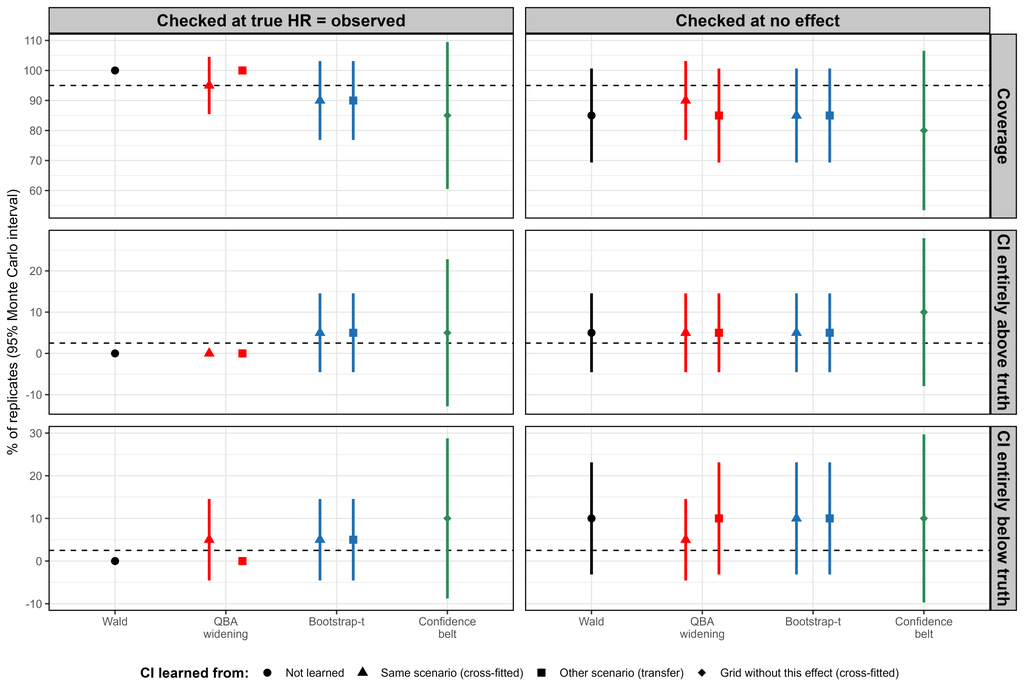

Figure 6: Coverage and one-sided misses of the Wald, QBA-widened, bootstrap-t and confidence-belt CIs. Bars: 95% Monte Carlo interval. Dashed: nominal value.

- **Transfer:** bootstrap-t 85.0% at no effect and 90.0% at the observed effect; QBA widening 85.0% and 100.0%; Wald 85.0% and 100.0%.
- $T$ is not fully pivotal: its quantiles shift with the true effect, so quantiles learned at one effect over-correct at the other.

**Confidence belt (test inversion).** The quantiles of $T$ depend on the true value (Neyman construction):

1. **Grid of true effects.** Besides θ* and 0, the study is replayed at 2 further values of θ, each with its own true value $\psi(\theta)$ (12 large datasets). The grid points are Chebyshev–Lobatto nodes in ψ over the range where CI endpoints fall (observed CI and the outer 0.5% of replicate Wald endpoints, widened by 10%), mapped to θ through a monotone spline of ψ(θ) through the true values and anchors at θ = ±2 and ±4 (3 large datasets each). Each point gets 1,000 replays first (same seeds), then more until the Monte Carlo SE of both quantiles of $T$ is below 0.05 (at most 5,000).
2. **Quantile curves.** A weighted polynomial in $\psi$ (degree 1) smooths the 2.5% and 97.5% quantiles of $T$ across the grid.
3. **Inversion.** The CI is every $\psi_0$ with $q_{2.5}(\psi_0) \le (\hat\psi - \psi_0)/\widehat{SE} \le q_{97.5}(\psi_0)$.

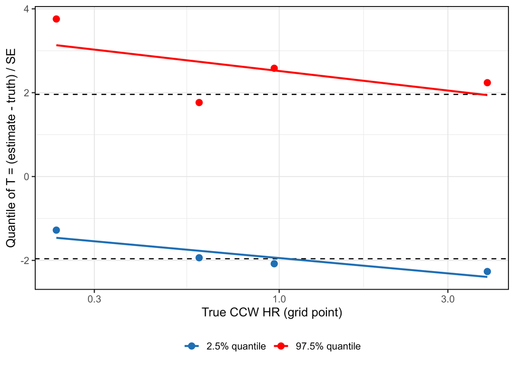

Figure 7: Quantiles of T across the grid of true effects (points) and the smoothed curves used for inversion. Dashed: ±1.96.

**Check** (the checked grid point is dropped and the curves refitted; MCSEs by bootstrap over replays, including the Monte Carlo error of the grid quantiles): observed effect, coverage 85.0% (MCSE 12.5%), 10.0% of CIs entirely below the truth and 5.0% above; no effect, coverage of ψ(0) = -0.041 (HR 0.9603, the CCW limit when surgery has no effect) 80.0% (MCSE 13.5%), 10.0% below and 10.0% above. The belt targets ψ(0) rather than the convention 0 used for the type I error, so whether a belt CI excludes HR = 1 is not a test of no effect. 30% (observed) and 0% (no effect) of replay CIs have an endpoint beyond the grid (θ within ±4), where the nearest quantile is used.

# 7. Alignment with the draft paper (version 0.65, 24 Oct)

| Draft paper | This run |
| --- | --- |
| 2.7.1: inverse calibration, m(θ*) = ψ̂<sub>obs</sub>; ψ(θ*) = plim of the reference analysis; ψ(θ*) = ψ̂<sub>obs</sub> − b(θ*) | **Implemented** (Section 2.2). |
| 2.7.2: non-parametric CI (add centred quantiles), validation in independent replicates | **Implemented**; reflected form reported alongside (Section 4). |
| 2.7.2: nested or double simulation | **Implemented** (Section 5); 1250 outer × 50 inner. |
| 2.7.3: centred null distribution, separate lower/upper limits, simulation-calibrated p, independent validation, directional rates | **Implemented**; rejection limits HR 0.5626 / 1.6453, p = 0.117. |
| 4.2: “The prediction model had 400,000 iterations.” | This run: 10,000 studies per scenario (main) + 10,000 per scenario (check) + 4,000 (calibration); nested 1250 + 1250 outer datasets. |
| 4.3: “Weibull generating HR of 0.49 to reproduce the observed CCW HR of 0.62” | exp(θ*) = 0.5052; mean CCW HR at θ* = 0.6160 (observed 0.6206). |
| 4.5 / Table 3: bias −0.015, coverage 93.6%, type I error 7.5% (7.6% in the text) | Bias -0.016, coverage 93.7%, type I error 7.550%. |
| 4.5: adjusted HR 0.6301, CI 0.37–1.08 | Simple: 0.6305 (0.3683–1.1216); nested: 0.3630–1.1227. |
| Table 2: “Calibrated critical value \|z\| for a 5% test 2.17” | Replaced by non-parametric limits; centred parametric critical value 2.07. |
| Start of the inverse calibration at θ = −0.7; grace period 180 days | **Implemented** (`calibration: start`, `grace`); θ* = -0.683 after 2 evaluations. |
| Endpoint: survival at 12 months (binary) | **Implemented** (Section 6.1). |
| RMSE and RMSE² in all outputs; no power | **Implemented** (Sections 1, 3, 4, A1). |
| 4.6: generalized-gamma prediction model | **Implemented** (Section 6.2; own store). |
| 4.6: bias correction for an estimator that is not consistent | **Implemented** (Section 6.3; hypothetical-trial target). |
| Appendix: optimal outer / inner split from a pilot | **Implemented** (Section 6.4); nested `outer` × `inner` in this run = 1250 × 50 (pilot of 50 × 50). |
| Comment on Figure 3: CI coverage not centred on 95% | Under adjustment: 94.9% (simple), 93.8% (nested), with MCSE in Section 4. |

# 8. Caveats and next steps

- **Truth definition.** ψ(θ) is the probability limit of the CCW analysis itself (paper 2.7.1). Any offset CCW keeps with unlimited data (here ψ(0) = -0.041) is therefore part of the truth at θ*, not of the bias. Defining ψ instead from pseudo-populations simulated under each strategy (one reading of 2.7.1 step 6c–e) would count that offset as bias.
- Truths are simulated (MCSE 0.005); this is included in the bias MCSE.
- The nested results carry the Monte Carlo error of 1250 outer datasets and 50 inner studies; increase both for the paper run if the precision is not sufficient.
- **Hypothetical trial (6.3).** The construction of the surgery arm and of the control censoring at day 181 is an implementation assumption; `rct: control_censor_day: null` follows the control arm to the end instead.
- **Risk difference (6.1).** The SE treats the IPC weights as known, as for the log HR.
- The Word draft of paper Section 4 (`reports/paper/section4_draft.docx`) uses the same results.

# Appendix

## A1. Performance in both scenarios

| Scenario | θ (DGM) | True HR | Mean HR | Bias (log HR) | MCSE | Emp. SE | Model SE | RMSE | MSE | Coverage | Reject HR = 1 | Mean deaths | Failed |
| --- | --- | --- | --- | --- | --- | --- | --- | --- | --- | --- | --- | --- | --- |
| Calibrated effect θ* | -0.68 | 0.6259 | 0.6160 | -0.016 | 0.006 | 0.285 | 0.274 | 0.285 | 0.0813 | 93.7% | NA% | 44.6 | 0 |
| No effect | 0.00 | 1.0000 | 0.9485 | -0.053 | 0.003 | 0.275 | 0.269 | 0.280 | 0.0786 | 92.5% | 7.550% | 54.9 | 0 |

## A2. Data-generating mechanism

**Kept fixed from the original data (paper Step 2):** covariates $X_i$ and each patient’s surgery date $s_i$ ($s_i = \infty$ if not operated). **Censoring:** $C_i = 365.24$ for all patients (no loss to follow-up; Section 2.3).

**Outcome model.** Weibull proportional hazards with surgery as a time-varying exposure:

$$h_i(t) = \lambda \rho\, t^{\rho - 1} \exp\{\gamma^\top X_i + \theta\, I(t \ge s_i)\}, \qquad \eta_i = \log\lambda + \gamma^\top X_i,$$

$$H_i(t) = e^{\eta_i}\left[\min(t, s_i)^{\rho} + e^{\theta}\,\max\{0,\; t^{\rho} - s_i^{\rho}\}\right].$$

Fitted by maximum likelihood (table below). In simulation, $\log\lambda$, $\rho$ and $\gamma$ are kept at their fitted values and $\theta$ is set to the scenario value ($\theta^*$ or 0); in the nested simulation all of them are refitted to each outer dataset. **Simulation by inversion** (common random numbers: $U_i$ depends only on the replicate seed, not on $\theta$), with $E_i = -\log U_i$:

$$T_i = \begin{cases} \left(E_i\, e^{-\eta_i}\right)^{1/\rho} & \text{if } E_i \le e^{\eta_i} s_i^{\rho} \text{ (death before surgery)},\\[4pt] \left\{ s_i^{\rho} + \left(E_i - e^{\eta_i} s_i^{\rho}\right) e^{-\eta_i - \theta} \right\}^{1/\rho} & \text{otherwise.} \end{cases}$$

Fitted Weibull model for death (hazard ratios).

| Term | HR | 95% CI |
| --- | --- | --- |
| Weibull shape (rho) | 1.29 |  |
| Age (per 5 years) | 0.9328 | 0.7102 to 1.2253 |
| Female | 0.4992 | 0.2678 to 0.9304 |
| Performance status 1 vs 0 | 1.0329 | 0.4419 to 2.4143 |
| Performance status 2 vs 0 | 2.4222 | 0.9315 to 6.2985 |
| TNM stage II vs I | 1.5921 | 0.8822 to 2.8731 |
| Deprivation score (per 0.1) | 0.9563 | 0.7516 to 1.2168 |
| Charlson index 1 vs 0 | 0.8601 | 0.4318 to 1.7132 |
| Charlson index 2 vs 0 | 1.0832 | 0.5035 to 2.3299 |
| Emergency presentation | 1.1949 | 0.5690 to 2.5090 |
| On treatment (time-varying) | 0.6605 | 0.3189 to 1.3684 |

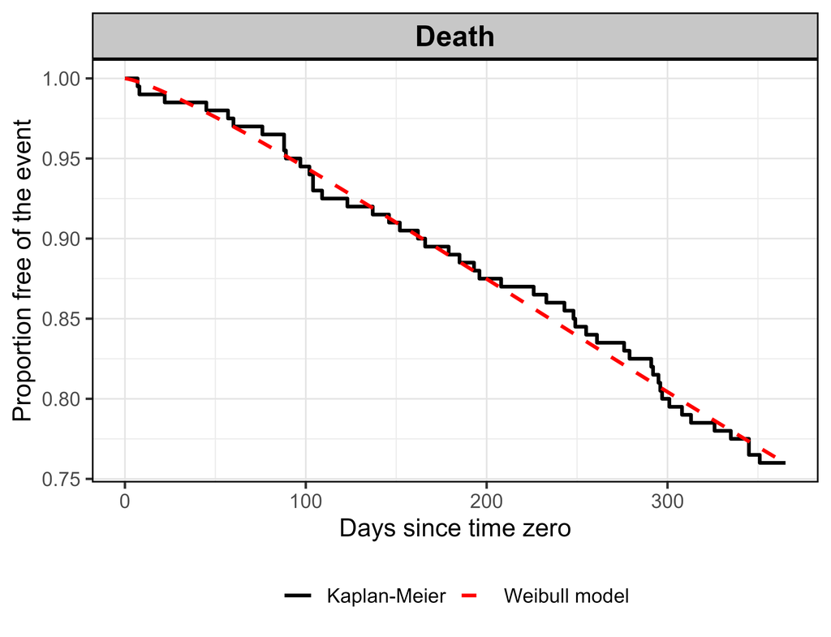

Figure 8: Fit of the Weibull model: Kaplan–Meier estimate in the original data and the survival predicted by the model (averaged over patients, each with their observed surgery date).

**R code: Weibull fit, censoring model and simulation (R/dgm.R)**

```r
#' Fit the reference DGM (outcome and censoring models) to the base data
#' @param data Base data from `prepare_base_data()`.
#' @param spec `cfg$dgm` (`family`: weibull, default, or gengamma);
#' @param cens_spec `cfg$censoring` (model: none, fixed or weibull).
#' @return Outcome-model list (see `fit_weibull_tv()`, `fit_gengamma_tv()`) with element `cens`.
fit_dgm <- function(data, spec, cens_spec = list(model = "fixed")) {
  checkmate::assert_data_table(data)
  checkmate::assert_choice(cens_spec$model, c("none", "fixed", "weibull"))
  family <- if (is.null(spec$family)) "weibull" else spec$family
  checkmate::assert_choice(family, c("weibull", "gengamma"))
  dgm <- if (family == "gengamma") {
    fit_gengamma_tv(data, spec$covariates, data$status)
  } else {
    c(list(family = "weibull"), fit_weibull_tv(data, spec$covariates, data$status))
  }
  # Censoring model: loss to follow-up is the event; outcome events and the horizon censor it
  dgm$cens <- if (cens_spec$model == "weibull") {
    c(list(model = "weibull"), fit_weibull_tv(data, cens_spec$covariates, data$cens_event))
  } else {
    list(model = cens_spec$model)
  }
  dgm
}

#' Invert the piecewise Weibull cumulative hazard (switch to exp(theta) at time s)
#' @param eta Linear predictor incl. intercept; @param rho Shape; @param theta Log-HR on treatment.
#' @param s Planned treatment time; @param u Uniforms.
#' @return Simulated times; the same u gives times monotone in theta.
invert_weibull_tv <- function(eta, rho, theta, s, u) {
  E <- -log(u)
  h_pre <- exp(eta) * s^rho
  data.table::fifelse(
    E <= h_pre,
    (E / exp(eta))^(1 / rho),
    (s^rho + (E - h_pre) / exp(eta + theta))^(1 / rho)
  )
}

#' Simulate event (and censoring) times for fixed baseline data and treatment plans
#' @param data Base data (covariates and planned treatment time `s` are kept).
#' @param dgm Fitted DGM from `fit_dgm()`.
#' @param theta Treatment log-HR used for simulation.
#' @param u,u_cens Uniforms for event and censoring times, one per patient (CRN).
#' @return Copy of `data` with simulated `time`, `status`, `cens_time`, `trt_time`, `cens_event`.
simulate_outcomes <- function(data, dgm, theta, u, u_cens = NULL) {
  checkmate::assert_numeric(u, len = nrow(data), lower = 0, upper = 1)
  X <- dgm_design(data, dgm$covariates)
  t_ev <- invert_dgm_tv(dgm, dgm$alpha + drop(X %*% dgm$gamma), theta, data$s, u)
  out <- data.table::copy(data)
  cm <- if (is.null(dgm$cens)) "fixed" else dgm$cens$model
  if (cm == "weibull") {
    checkmate::assert_numeric(u_cens, len = nrow(data), lower = 0, upper = 1)
    cs <- dgm$cens
    Xc <- dgm_design(data, cs$covariates)
    # Censoring hazard also changes at treatment start; theta_c is kept as fitted
    eta_c <- cs$alpha + drop(Xc %*% cs$gamma)
    t_c <- invert_weibull_tv(eta_c, cs$rho, cs$theta_hat, data$s, u_cens)
    out[, cens_time := pmin(t_c, admin_time)]
  }
  out[, `:=`(time = pmin(t_ev, cens_time), status = as.integer(t_ev <= cens_time))]
  out[, trt_time := data.table::fifelse(s <= time, s, Inf)]
  # Simulated loss to follow-up, so a refit of the censoring model (nested simulation) sees it
  out[, cens_event := as.integer(status == 0L & time < admin_time)]
  out[]
}
```

## A3. Censoring weights and outcome model

Grace period $g = 180$ days; $Z$ = age, sex, performance status, stage, deprivation, Charlson index, emergency presentation.

- *Arm 0, no surgery within $g$.* Censored at surgery: $C^a_i = s_i$ if $s_i \le \min(g, Y_i)$. Cox model for time to surgery with Breslow baseline; weights updated at every distinct surgery date, $W_i(t) = 1/\hat S^c(t \mid Z_i) = \exp\{\hat\Lambda^c_0(\min(t, g))\, e^{\hat\beta^\top Z_i}\}$.
- *Arm 1, surgery within $g$.* Censored at $g$ if alive and not operated. Logistic model among patients alive at $g$, $\pi(Z) = P(s \le g \mid Z, Y > g)$; $W_i(t) = 1$ for $t < g$ and $1/\hat\pi(Z_i)$ for $t \ge g$.
- *Outcome model.* Weighted Cox model on the stacked clones, $\lambda(t \mid A) = \lambda_0(t)\, e^{\psi A}$, Efron ties, robust SE clustered on patient, Wald 95% CI.

**R code: cloning, weights and outcome model (R/pipeline.R)**

```r
#' Clone into "surgery within grace" (arm 1) and "no surgery within grace" (arm 0)
#' @param data Patient-level data; @param grace Grace period (days).
#' @return Clone rows: arm, end, event, art_cens.
build_clones <- function(data, grace) {
  ctrl <- data.table::copy(data)[, arm := 0L]
  ctrl[, art_cens := as.integer(trt_time <= grace)]
  ctrl[, `:=`(
    end = data.table::fifelse(art_cens == 1L, trt_time, time),
    event = data.table::fifelse(art_cens == 1L, 0L, status)
  )]
  surg <- data.table::copy(data)[, arm := 1L]
  # Deaths before grace without surgery stay in the surgery arm (Maringe et al. 2020)
  surg[, art_cens := as.integer(trt_time > grace & time > grace)]
  surg[, `:=`(
    end = data.table::fifelse(art_cens == 1L, grace, time),
    event = data.table::fifelse(art_cens == 1L, 0L, status)
  )]
  data.table::rbindlist(list(ctrl, surg))
}

#' Inverse probability of censoring weights for the control arm (Cox censoring model)
#' @param clones Control-arm clones; @param spec Pipeline spec.
#' @return Long data split at censoring times, with weight `w` = 1 / P(uncensored at start).
weight_control <- function(clones, spec) {
  f <- stats::reformulate(spec$cens_covariates, response = "survival::Surv(end, art_cens)")
  fit <- survival::coxph(f, data = clones, ties = "breslow")
  bh <- survival::basehaz(fit, centered = FALSE)
  clones[, lp := stats::predict(fit, type = "lp", reference = "zero")]
  # Split at the observed censoring (surgery) times: weights change only there
  ctimes <- sort(unique(clones[art_cens == 1L, end]))
  brk <- unique(c(0, ctimes[ctimes < spec$grace], spec$grace))
  long <- split_clones(clones, brk)
  H0 <- stats::stepfun(bh$time, c(0, bh$hazard))
  # Right-continuous: those censored at a break have left the risk set
  long[, w := exp(H0(pmin(start, spec$grace)) * exp(lp))]
  long[]
}

#' Inverse probability of censoring weights for the surgery arm
#' @param clones Surgery-arm clones; @param data Patient data; @param spec Pipeline spec.
#' @return Long data split at grace, with weight `w`.
weight_surgery <- function(clones, data, spec) {
  long <- split_clones(clones, c(0, spec$grace))
  # Censoring happens only at grace end, for patients alive and not yet operated
  alive <- data[time > spec$grace]
  alive[, op := as.integer(trt_time <= spec$grace)]
  f <- stats::reformulate(spec$cens_covariates, response = "op")
  fit <- stats::glm(f, family = stats::binomial(), data = alive)
  alive[, p_op := stats::predict(fit, type = "response")]
  long[, w := 1]
  long[alive, on = "id", p_op := i.p_op]
  long[start >= spec$grace, w := 1 / p_op]
  long[]
}

#' Weighted Cox model for the strategy contrast
#' @param long Stacked long data (id, arm, start, stop, ev, w); @param spec Pipeline spec.
#' @param robust Robust (cluster) SE; FALSE only for large-sample truth runs.
#' @return One-row data.table in the pipeline contract format.
fit_outcome <- function(long, spec, robust) {
  fit <- if (robust) {
    survival::coxph(
      survival::Surv(start, stop, ev) ~ arm,
      data = long, weights = w, cluster = id, ties = "efron"
    )
  } else {
    survival::coxph(survival::Surv(start, stop, ev) ~ arm, data = long, weights = w, ties = "efron")
  }
  est <- unname(stats::coef(fit)["arm"])
  se <- unname(sqrt(stats::vcov(fit)["arm", "arm"]))
  z <- stats::qnorm(1 - (1 - spec$conf_level) / 2)
  data.table::data.table(
    estimate = est, se = se, ci_lo = est - z * se, ci_hi = est + z * se,
    p_value = 2 * stats::pnorm(-abs(est / se)), n_events = sum(long$ev),
    status = "ok", message = NA_character_
  )
}
```

## A4. Truth, calibration, adjustment and nested simulation

**R code: calibration, simple adjustment and nested outer replicate (R/truth.R, R/correction.R, R/nested.R)**

```r
#' Inverse calibration: theta whose mean simulated estimate m(theta) equals a target (paper 2.7.1)
#' The search starts at `start[1]` and stops there if m is already within `cc$tol` of the target.
#' @param dgm Fitted DGM; @param data Base data; @param target Estimate to reproduce.
#' @param seeds Replicate seeds, reused at every theta (CRN makes m(theta) smooth and monotone).
#' @param pipeline Pipeline spec; @param cc List with max_iter, tol, bound.
#' @param start First theta (default `cc$start`); an optional second element is the second point.
#' @param slope Expected dm/dtheta; if given, the second point is a Newton step from `start[1]`;
#'   without it the second point is `start[2]` or, if absent, a unit-slope step.
#' @return List: theta_cal, mean_est, mean_est_mcse, n_ok, estimates (at theta_cal), slope,
#'   at_bound, n_eval, path.
calibrate_mean <- function(dgm, data, target, seeds, pipeline, cc, start = cc$start, slope = NULL) {
  checkmate::assert_number(target)
  checkmate::assert_numeric(start, min.len = 1, any.missing = FALSE)
  clamp <- function(x) max(-cc$bound, min(cc$bound, x))
  evals <- list()
  run_at <- function(th) {
    est <- replicate_estimates(data, dgm, th, seeds, pipeline)
    evals[[length(evals) + 1L]] <<- list(theta = th, m = mean(est, na.rm = TRUE), est = est)
  }
  prior_slope <- if (is.null(slope)) 1 else slope
  last_slope <- function() {
    n <- length(evals)
    if (n < 2L) return(prior_slope)
    s <- (evals[[n]]$m - evals[[n - 1L]]$m) / (evals[[n]]$theta - evals[[n - 1L]]$theta)
    # A flat or undefined secant (failed fits, same theta) falls back to the prior slope
    if (is.finite(s) && abs(s) > 1e-8) s else prior_slope
  }
  run_at(clamp(start[1]))
  if (is.finite(evals[[1]]$m) && abs(evals[[1]]$m - target) >= cc$tol) {
    th2 <- if (!is.null(slope)) {
      clamp(evals[[1]]$theta + (target - evals[[1]]$m) / slope)
    } else if (length(start) >= 2L) {
      start[2]
    } else {
      clamp(evals[[1]]$theta + (target - evals[[1]]$m))
    }
    if (abs(th2 - evals[[1]]$theta) > 1e-6) run_at(th2)
  }
  for (i in seq_len(cc$max_iter)) {
    n <- length(evals)
    if (!is.finite(evals[[n]]$m) || abs(evals[[n]]$m - target) < cc$tol) break
    th_new <- clamp(evals[[n]]$theta + (target - evals[[n]]$m) / last_slope())
    if (abs(th_new - evals[[n]]$theta) < 1e-6) break
    run_at(th_new)
  }
  path <- data.table::rbindlist(lapply(seq_along(evals), function(k) {
    data.table::data.table(step = k, theta = evals[[k]]$theta, mean_est = evals[[k]]$m,
                           n_ok = sum(!is.na(evals[[k]]$est)))
  }))
  if (!any(is.finite(path$mean_est))) {
    cli::cli_abort("All simulated analyses failed in calibration.")
  }
  best <- which.min(abs(path$mean_est - target))
  est <- evals[[best]]$est
  list(
    theta_cal = path$theta[best],
    mean_est = path$mean_est[best],
    mean_est_mcse = stats::sd(est, na.rm = TRUE) / sqrt(sum(!is.na(est))),
    n_ok = sum(!is.na(est)),
    estimates = est,
    slope = last_slope(),
    at_bound = abs(path$theta[best]) >= cc$bound,
    n_eval = nrow(path),
    path = path
  )
}

#' Simple QBA adjustment of the observed analysis (paper 2.7.1-2.7.3)
#' @param obs_result Observed pipeline result.
#' @param sim_results Main replicates at the calibrated theta and at theta = 0.
#' @param truth_table From `make_truth_table()`; @param dataset Dataset key.
#' @param level Nominal level; @param favours_low TRUE if a smaller estimate favours arm 1 (log HR).
#' @return One-row data.table on the scale of the endpoint.
adjust_simple <- function(obs_result, sim_results, truth_table, dataset, level = 0.95,
                          favours_low = TRUE) {
  z <- stats::qnorm(1 - (1 - level) / 2)
  tt <- truth_table[scenario == "observed"]
  o <- sim_results[theta == tt$theta & !is.na(estimate)]
  n0 <- sim_results[theta == 0 & !is.na(estimate) & !is.na(se)]
  m <- mean(o$estimate)
  # Bias at the calibrated value; since m(theta_cal) = observed, psi(theta_cal) = observed - bias
  bias <- m - tt$truth
  est_adj <- obs_result$estimate - bias
  q <- centred_quantiles(o$estimate, level)
  emp_se <- stats::sd(o$estimate)
  k <- emp_se / sqrt(mean(o$se^2, na.rm = TRUE))
  # No effect: rejection limits from the centred null distribution (paper 2.7.3, steps 6-7)
  m0 <- mean(n0$estimate)
  e0 <- n0$estimate - m0
  q0 <- centred_quantiles(n0$estimate, level)
  d_obs <- obs_result$estimate - m0
  z0 <- abs(e0 / n0$se)
  z_obs <- abs(d_obs / obs_result$se)
  z_crit <- stats::quantile(z0, level, names = FALSE, type = 8)
  data.table::data.table(
    dataset = dataset, theta_cal = tt$theta,
    est_obs = obs_result$estimate, se_obs = obs_result$se,
    ci_lo_obs = obs_result$ci_lo, ci_hi_obs = obs_result$ci_hi, p_obs = obs_result$p_value,
    n_sim = nrow(o), mean_est = m, mean_est_mcse = emp_se / sqrt(nrow(o)),
    calib_resid = obs_result$estimate - m,
    truth = tt$truth, truth_mcse = tt$truth_mcse, bias = bias,
    # Truth is itself simulated: its MC error adds to that of the mean estimate
    bias_mcse = sqrt(emp_se^2 / nrow(o) + tt$truth_mcse^2),
    est_adj = est_adj,
    q_lo = q[["q_lo"]], q_hi = q[["q_hi"]],
    # Paper 2.7.2, step 5a: add the centred quantiles to the adjusted estimate
    ci_lo_np = est_adj + q[["q_lo"]], ci_hi_np = est_adj + q[["q_hi"]],
    # Reflected (basic bootstrap) form: matches the paper's form when the errors are symmetric
    ci_lo_np_refl = est_adj - q[["q_hi"]], ci_hi_np_refl = est_adj - q[["q_lo"]],
    emp_se = emp_se, mod_se = sqrt(mean(o$se^2, na.rm = TRUE)), se_inflation = k,
    ci_lo_par = est_adj - z * k * obs_result$se, ci_hi_par = est_adj + z * k * obs_result$se,
    n_null = nrow(n0), null_mean = m0, null_q_lo = q0[["q_lo"]], null_q_hi = q0[["q_hi"]],
    reject_np = d_obs < q0[["q_lo"]] | d_obs > q0[["q_hi"]],
    # Two-sided p from the centred null distribution (equal tails, as the rejection limits)
    p_np = min(1, 2 * min(mean(e0 <= d_obs), mean(e0 >= d_obs))),
    z_crit_par = z_crit, z_obs_centred = z_obs, reject_par = z_obs > z_crit,
    p_par = mean(z0 >= z_obs), favours_low = favours_low
  )
}

#' One outer replicate at the calibrated effect (paper 2.7.2, nested steps 2-8)
#' @param data Base data; @param dgm Fitted DGM; @param calibration From `calibrate_observed()`.
#' @param rep,seed Outer replicate index and seed; @param spec Dataset entry of `cfg$datasets`.
#' @param cfg Full config (uses `nested`, `calibration$bound`); @param level Nominal level.
#' @param keep_inner Keep the inner estimates at theta_r in list column `inner_est` (pilot only).
#' @return One-row data.table (see `nested_cols`); `seconds_cal` is the time of the inner
#'   simulations (calibration steps), `seconds` the whole outer replicate.
nested_outer_one <- function(data, dgm, calibration, rep, seed, spec, cfg, level = 0.95,
                             keep_inner = FALSE) {
  t0 <- proc.time()[["elapsed"]]
  nc <- cfg$nested
  rng <- draw_replicate_rng(seed, nrow(data))
  sim <- simulate_outcomes(data, dgm, calibration$theta_cal, rng$u_event, rng$u_cens)
  res <- safely_run(run_pipeline, sim, spec$pipeline)
  if (is.na(res$estimate)) {
    return(nested_fail_row(rep, seed, res, "error", res$message, nested_cols))
  }
  out <- tryCatch({
    # Refit the prediction model to the outer dataset, as for the study data
    dgm_r <- fit_dgm(sim, spec$dgm, spec$censoring)
    sd <- nested_seeds(rng$seed_aux, nc$inner)
    scale <- if (is.null(spec$tol_scale)) 1 else spec$tol_scale
    cc <- list(max_iter = nc$max_iter, tol = nc$tol * scale, bound = cfg$calibration$bound)
    t_cal <- proc.time()[["elapsed"]]
    cal <- calibrate_mean(dgm_r, data, res$estimate, sd$inner, spec$pipeline, cc,
                          start = calibration$theta_cal, slope = calibration$slope)
    seconds_cal <- proc.time()[["elapsed"]] - t_cal
    tr <- compute_truth(dgm_r, data, cal$theta_cal, spec$pipeline, cfg, n_rep = nc$truth_n_rep,
                        n_target = nc$truth_n_target, seed = sd$truth)
    est_in <- cal$estimates[!is.na(cal$estimates)]
    bias_r <- mean(est_in) - tr$truth
    est_adj <- res$estimate - bias_r
    q <- centred_quantiles(est_in, level)
    data.table::data.table(
      rep = rep, seed = seed, estimate = res$estimate, se = res$se,
      theta_hat_r = dgm_r$theta_hat, theta_r = cal$theta_cal, n_eval = cal$n_eval,
      at_bound = as.numeric(cal$at_bound), mean_inner = mean(est_in),
      mean_inner_mcse = stats::sd(est_in) / sqrt(length(est_in)), n_inner_ok = length(est_in),
      truth_r = tr$truth, truth_r_mcse = tr$truth_mcse, bias_r = bias_r, est_adj = est_adj,
      q_lo = q[["q_lo"]], q_hi = q[["q_hi"]],
      ci_lo_np = est_adj + q[["q_lo"]], ci_hi_np = est_adj + q[["q_hi"]],
      ci_lo_np_refl = est_adj - q[["q_hi"]], ci_hi_np_refl = est_adj - q[["q_lo"]],
      seconds = NA_real_, seconds_cal = seconds_cal, status = res$status, message = res$message
    )
  }, error = function(e) {
    nested_fail_row(rep, seed, res, "error_nested", conditionMessage(e), nested_cols)
  })
  if (keep_inner && !is.na(out$est_adj)) out[, inner_est := list(list(est_in))]
  out[, seconds := proc.time()[["elapsed"]] - t0]
  out[]
}
```

## A5. Settings and software

Common random numbers across scenarios; seeds and all settings in `config/config.yml`; design in `protocol/ADEMP.md`; pipeline structure in `docs/technical_setup.html`. Run time: Section 1.2.

R version 4.6.1 (2026-06-24 ucrt); data.table 1.18.6.1, survival 3.8-12, targets 1.12.0.